# Cluster-Based Permutation Tests

# Method

# Clusters significant after correction

**Verb violation at the suffix**

- LAN, 225 to 300 ms. L1 at pre. Verb mismatch was more negative than verb match at 21 electrodes (F3, FC5, FC1, C3, CP5, CP1, Pz, P3, P7, O1, Oz, P4, P8, CP6, CP2, Cz, C4, FC6, FC2, F4, FCz; largest at C4; mean difference −1.00 µV; cluster *p* < .001, corrected *p* = .003). The cluster was significant after correction.
- LAN, 225 to 300 ms. L1 at post. Verb mismatch was more negative than verb match at 16 electrodes (F3, FC5, FC1, C3, T7, CP5, P7, CP6, CP2, Cz, C4, T8, FC6, FC2, F4, FCz; largest at F3; mean difference −0.79 µV; cluster *p* = .003, corrected *p* = .006). The cluster was significant after correction.

# Clusters at *p* < .05 before correction only

**Verb violation at the suffix**

- P600, 500 to 700 ms. L1 at post. Verb mismatch was more positive than verb match at 8 electrodes (Pz, P3, P7, O1, Oz, O2, P4, P8; largest at P7; mean difference 1.02 µV; cluster *p* = .022, corrected *p* = .090). The cluster was not significant after correction.

**Verb stress at verb F0**

- PrAN, 136 to 280 ms. L2 at post. Oxytone was more negative than paroxytone at 13 electrodes (F3, F7, FC5, FC1, C3, Cz, C4, T8, FC6, FC2, F4, F8, FCz; largest at F8; mean difference −0.65 µV; cluster *p* = .018, corrected *p* = .070). The cluster was not significant after correction.

**Noun cue at noun F0**

- PrAN, 136 to 200 ms. L1 at post. Oxytone cue was more negative than paroxytone cue at 9 electrodes (F3, F7, FC5, C3, T7, CP5, Pz, P3, Cz; largest at CP5; mean difference −0.34 µV; cluster *p* = .026, corrected *p* = .104). The cluster was not significant after correction.

# Verb violation at the suffix

**LAN, 225 to 300 ms**

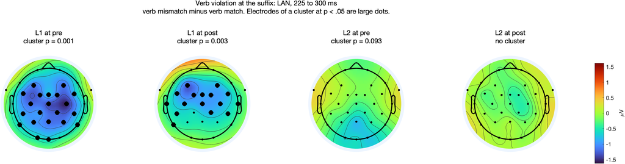

- **L1 at pre.** Verb mismatch was more negative than verb match at 21 electrodes (F3, FC5, FC1, C3, CP5, CP1, Pz, P3, P7, O1, Oz, P4, P8, CP6, CP2, Cz, C4, FC6, FC2, F4, FCz; largest at C4; mean difference −1.00 µV; cluster *p* < .001, corrected *p* = .003). The cluster was significant after correction.
- **L1 at post.** Verb mismatch was more negative than verb match at 16 electrodes (F3, FC5, FC1, C3, T7, CP5, P7, CP6, CP2, Cz, C4, T8, FC6, FC2, F4, FCz; largest at F3; mean difference −0.79 µV; cluster *p* = .003, corrected *p* = .006). The cluster was significant after correction.
- **L2 at pre.** No significant cluster. In the largest cluster, verb mismatch was more negative than verb match at 4 electrodes (Pz, O1, Oz, O2; largest at O2; mean difference −0.71 µV; cluster *p* = .093, corrected *p* = .124).
- **L2 at post.** No cluster was formed.

**N400, 300 to 500 ms**

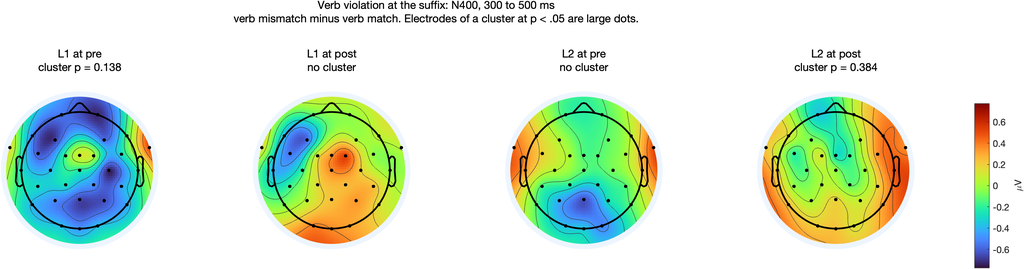

- **L1 at pre.** No significant cluster. In the largest cluster, verb mismatch was more negative than verb match at 3 electrodes (Pz, P4, C4; largest at C4; mean difference −0.68 µV; cluster *p* = .138, corrected *p* = .550).
- **L1 at post.** No cluster was formed.
- **L2 at pre.** No cluster was formed.
- **L2 at post.** No significant cluster. In the largest cluster, verb mismatch was more positive than verb match at 1 electrode (T8; largest at T8; mean difference 0.49 µV; cluster *p* = .384, corrected *p* = .769).

**P600, 500 to 700 ms**

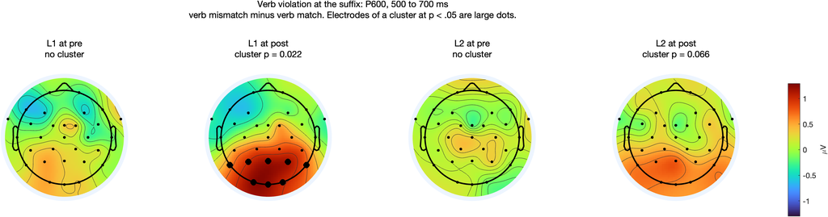

- **L1 at pre.** No cluster was formed.
- **L1 at post.** Verb mismatch was more positive than verb match at 8 electrodes (Pz, P3, P7, O1, Oz, O2, P4, P8; largest at P7; mean difference 1.02 µV; cluster *p* = .022, corrected *p* = .090). The cluster was not significant after correction.
- **L2 at pre.** No cluster was formed.
- **L2 at post.** No significant cluster. In the largest cluster, verb mismatch was more positive than verb match at 5 electrodes (P7, O1, Oz, O2, P8; largest at P7; mean difference 0.63 µV; cluster *p* = .066, corrected *p* = .131).

# Verb stress at verb F0

**PrAN, 136 to 280 ms**

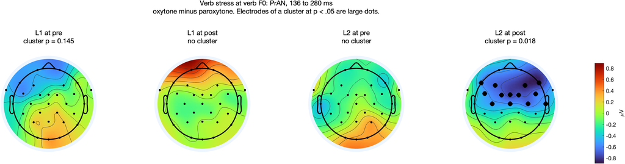

- **L1 at pre.** No significant cluster. In the largest cluster, oxytone was more negative than paroxytone at 3 electrodes (F7, FT9, FC5; largest at FT9; mean difference −0.51 µV; cluster *p* = .145, corrected *p* = .290).
- **L1 at post.** No cluster was formed.
- **L2 at pre.** No cluster was formed.
- **L2 at post.** Oxytone was more negative than paroxytone at 13 electrodes (F3, F7, FC5, FC1, C3, Cz, C4, T8, FC6, FC2, F4, F8, FCz; largest at F8; mean difference −0.65 µV; cluster *p* = .018, corrected *p* = .070). The cluster was not significant after correction.

**PrAN after an oxytone noun cue (conditions 4, 5, and 6), 136 to 280 ms**

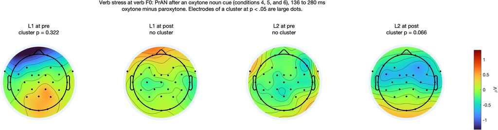

- **L1 at pre.** No significant cluster. In the largest cluster, oxytone was more negative than paroxytone at 1 electrode (F7; largest at F7; mean difference −0.93 µV; cluster *p* = .322, corrected *p* = .643).
- **L1 at post.** No cluster was formed.
- **L2 at pre.** No cluster was formed.
- **L2 at post.** No significant cluster. In the largest cluster, oxytone was more negative than paroxytone at 5 electrodes (C4, T8, FC6, FC2, F4; largest at T8; mean difference −0.67 µV; cluster *p* = .066, corrected *p* = .262).

**PrAN after a paroxytone noun cue (conditions 1, 3, and 2), 136 to 280 ms**

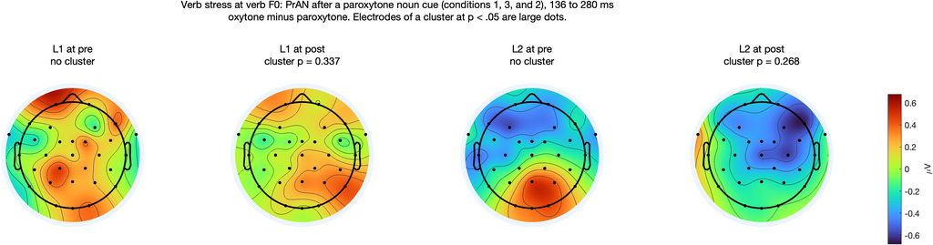

- **L1 at pre.** No cluster was formed.
- **L1 at post.** No significant cluster. In the largest cluster, oxytone was more positive than paroxytone at 1 electrode (P8; largest at P8; mean difference 0.43 µV; cluster *p* = .337, corrected *p* = .674).
- **L2 at pre.** No cluster was formed.
- **L2 at post.** No significant cluster. In the largest cluster, oxytone was more negative than paroxytone at 1 electrode (F8; largest at F8; mean difference −0.65 µV; cluster *p* = .268, corrected *p* = .674).

**PrAN after an oxytone against after a paroxytone noun cue, 136 to 280 ms**

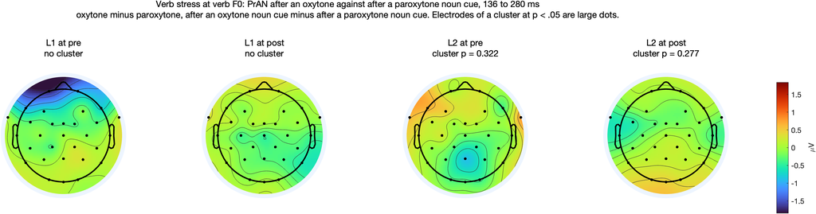

# Noun cue at noun F0

**PrAN, 136 to 200 ms**

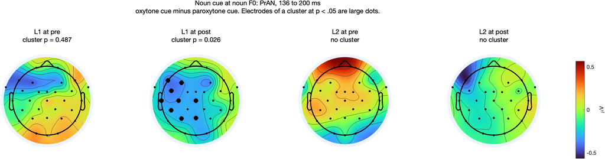

- **L1 at pre.** No significant cluster. In the largest cluster, oxytone cue was more negative than paroxytone cue at 1 electrode (F3; largest at F3; mean difference −0.44 µV; cluster *p* = .487, corrected *p* = .974).
- **L1 at post.** Oxytone cue was more negative than paroxytone cue at 9 electrodes (F3, F7, FC5, C3, T7, CP5, Pz, P3, Cz; largest at CP5; mean difference −0.34 µV; cluster *p* = .026, corrected *p* = .104). The cluster was not significant after correction.
- **L2 at pre.** No cluster was formed.
- **L2 at post.** No cluster was formed.

# Noun violation at verb F0

**LAN, 225 to 300 ms**

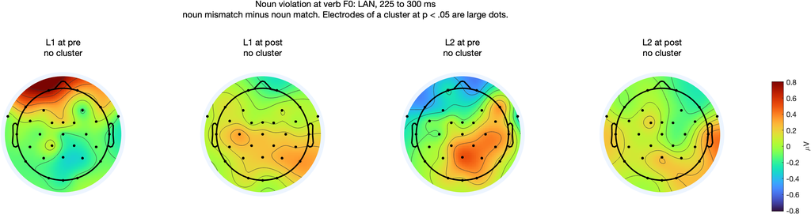

- **L1 at pre.** No cluster was formed.
- **L1 at post.** No cluster was formed.
- **L2 at pre.** No cluster was formed.
- **L2 at post.** No cluster was formed.

**N400, 300 to 500 ms**

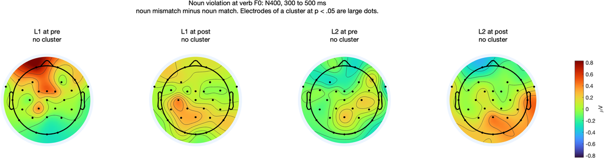

- **L1 at pre.** No cluster was formed.
- **L1 at post.** No cluster was formed.
- **L2 at pre.** No cluster was formed.
- **L2 at post.** No cluster was formed.

**P600, 500 to 700 ms**

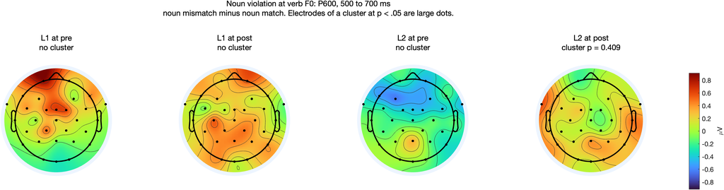

- **L1 at pre.** No cluster was formed.
- **L1 at post.** No cluster was formed.
- **L2 at pre.** No cluster was formed.
- **L2 at post.** No significant cluster. In the largest cluster, noun mismatch was more positive than noun match at 1 electrode (FT9; largest at FT9; mean difference 0.60 µV; cluster *p* = .409, corrected *p* = 1.000).

# Verb stress at verb F0 during training

**PrAN, 136 to 280 ms**

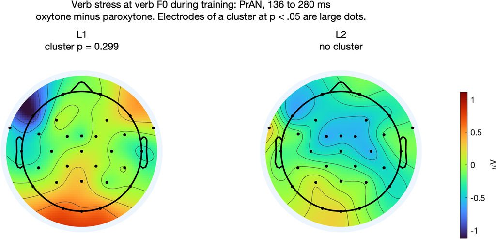

- **L1.** No significant cluster. In the largest cluster, oxytone was more negative than paroxytone at 1 electrode (F7; largest at F7; mean difference −1.06 µV; cluster *p* = .299, corrected *p* = .598).
- **L2.** No cluster was formed.